# 2. patch analysis

Johannes De Groeve

1/27/2021

### packages

```r
library(reshape)
library(ggplot2)
library(dplyr)
library(yarrr)
source('./fncs/21_patch_statistics.R')
```

### data

Dataset including the patch size for every location of roe and red deer location dataset.

- **aniyr**: unique identifier for animal-year
- **study_areas_id**: unique identifier study area as defined in the eurodeer database
- **sex**: biological sex of the animal
- **animals_id**: unique identifier of animal as defined in the eurodeer database
- **acquisition_time**: UTC date and time corresponding to a location
- **x**: x-coordinate of the location using Spatial Reference Identifier SRID 3035
- **y**: y-coordinate of the location using Spatial Reference Identifier SRID 3035
- **forest_density**: forest density percentage of the location as defined by the Tree Cover Density Dataset (TCD)
- **corine_land_cover_2012_vector_code**: land cover classification code of the location as defined by Corine Land Cover - Vector (CLC).
- **timex**: time in utc
- **datex**: date
- **yearx**: year
- **mid_or_noon**: midnight or noon
- **doyx**: day of the year
- **min**: minimum doy in dataset
- **max**: maximum doy in dataset
- **diff_doy**: total number of days as defined by the interval (minimum doy to maximum doy)
- **timex**: time in utc
- **prop**: overall proportion of locations in the forest as defined by TCD
- **prop_night**: proportion of locations in the forest during the night as defined by TCD
- **prop_day**: proportion of locations in the forest during the day as defined by TCD
- **count**: overall number of locations on which calculations are based
- **count_night**: number of locations during the night on which calculations are based
- **count_day**: number of locations during the day on which calculations are based
- **TCD_forest_patch_size**: patch size in squared meter of forest patch of a location as defined by TCD
- **CLC_forest_patch_size**: patch size in squared meter of forest patch of a location as defined by CLC
- **TCD_open_patch_size**: patch size in squared meter of open patch of a location as defined by TCD
- **CLC_open_patch_size**: patch size in squared meter of open patch of a location as defined by CLC

```r
ce <- read.csv2('../data/2_patchsize/red.csv',dec = ',')
ca <- read.csv2('../data/2_patchsize/roe.csv',dec = ',')
head(ce)
```

```
##   X    aniyr study_areas_id sex animals_id       acquisition_time
## 1 1 113_2011              3   m        113 2011-05-01 01:00:41+00
## 2 2 113_2011              3   m        113 2011-05-01 12:00:53+00
## 3 3 113_2011              3   m        113 2011-05-02 00:00:24+00
## 4 4 113_2011              3   m        113 2011-05-02 12:00:47+00
## 5 5 113_2011              3   m        113 2011-05-02 23:00:42+00
## 6 6 113_2011              3   m        113 2011-05-03 11:02:01+00
##   forest_density corine_land_cover_2012_vector_code    timex      datex yearx
## 1              0                                231 01:00:41 2011-05-01  2011
## 2             97                                312 12:00:53 2011-05-01  2011
## 3             93                                231 00:00:24 2011-05-02  2011
## 4             98                                312 12:00:47 2011-05-02  2011
## 5              0                                211 23:00:42 2011-05-03  2011
## 6             98                                312 11:02:01 2011-05-03  2011
##   mid_or_noon doyx min max diff_doy      prop count cnt_night prop_night
```

[output cut: 20 more lines]

```r
head(ca)
```

```
##        X    aniyr study_areas_id sex animals_id       acquisition_time
## 1 103311 769_2005              1   m        769 2005-05-01 00:02:54+00
## 2 103312 769_2005              1   m        769 2005-05-01 12:01:59+00
## 3 103313 769_2005              1   m        769 2005-05-02 00:03:00+00
## 4 103314 769_2005              1   m        769 2005-05-07 12:03:05+00
## 5 103315 769_2005              1   m        769 2005-05-08 00:02:12+00
## 6 103316 769_2005              1   m        769 2005-05-08 12:02:22+00
##   forest_density corine_land_cover_2012_vector_code    timex      datex yearx
## 1             99                                313 00:02:54 2005-05-01  2005
## 2             86                                311 12:01:59 2005-05-01  2005
## 3             97                                311 00:03:00 2005-05-02  2005
## 4             89                                311 12:03:05 2005-05-07  2005
## 5             94                                311 00:02:12 2005-05-08  2005
## 6             98                                311 12:02:22 2005-05-08  2005
##   mid_or_noon doyx min max diff_doy      prop count cnt_night prop_night
```

[output cut: 20 more lines]

### Apply patch_stat function

```r
# CALCULATE NUMBER OF PATCHES AND NUMBER OF FIXES IN A PATCH SMALLER THAN 25 HECTARE
patch_ce_l <- patch_statistics(ce, patchsize = 250000)
patch_ca_l <- patch_statistics(ca, patchsize = 250000)
```

### nr of small patches

First, we calculated the number of patches per individual. Then we sum up all the patches over all populations per species.

```r
# NR OF PATCHES
patch_nr_ce <- patch_ce_l[[1]]
patch_nr_ce$species <- 'red'
patch_nr_ca <- patch_ca_l[[1]]
patch_nr_ca$species <- 'roe'

patch_nr <- rbind(patch_nr_ce,patch_nr_ca)
patch_nr <- melt(patch_nr, id=c("species","animals_id"))

# STATISTICS ABOUT NR OF PATCHES PER INDIVIDUAL OVER ALL POPULATIONS PER SPECIES
(r <- group_by(patch_nr, species, variable) %>%
    summarise(sum = sum(value),
              mean= mean(value),
              median=median(value),
              max=max(value),
              min=min(value)))
```

```
## # A tibble: 8 × 7
## # Groups:   species [2]
##   species variable   sum  mean median   max   min
##   <chr>   <fct>    <int> <dbl>  <int> <int> <int>
## 1 red     TCD_F      406  4.78      3    18     2
## 2 red     CLC_F      208  2.45      2     6     2
## 3 red     TCD_O      707  8.32      8    20     2
## 4 red     CLC_O      269  3.16      3     7     2
## 5 roe     TCD_F      490  4.67      3    27     1
## 6 roe     CLC_F      223  2.12      2     4     1
## 7 roe     TCD_O      340  3.24      2     9     1
## 8 roe     CLC_O      231  2.2       2     6     1
```

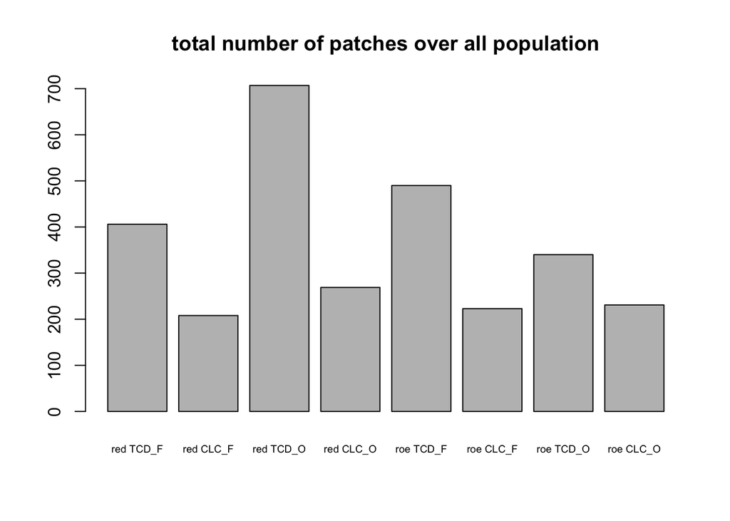

```r
barplot(r$sum,
        cex.names=0.6,
        names.arg=c(paste0(r$species, ' ' , r$variable)),
        main='total number of patches over all population')
```

### nr of fixes in patches < 25 hectares

First, we calculated the proportion of fixes that is in a patch smaller than 25 hectare, for each individual. Then, we calculate the mean of that proportion over all populations (and thus all individuals)

```r
patch_fx_ce <- patch_ce_l[[2]]
patch_fx_ce$species <- 'red'
patch_fx_ca <- patch_ca_l[[2]]
patch_fx_ca$species <- 'roe'

patch_fx <- rbind(patch_fx_ce,patch_fx_ca)
(r <- group_by(patch_fx, species, variable) %>%
    summarise(mean= mean(Freq),
              median=median(Freq),
              max=max(Freq),
              min=min(Freq)))
```

```
## # A tibble: 8 × 6
## # Groups:   species [2]
##   species variable    mean  median    max   min
##   <chr>   <chr>      <dbl>   <dbl>  <dbl> <dbl>
## 1 red     CLC_F    0.00663 0       0.543      0
## 2 red     CLC_O    0.00122 0       0.0556     0
## 3 red     TCD_F    0.0451  0.00549 0.779      0
## 4 red     TCD_O    0.432   0.238   1          0
## 5 roe     CLC_F    0.103   0       1          0
## 6 roe     CLC_O    0.0528  0       1          0
## 7 roe     TCD_F    0.389   0.0599  1          0
## 8 roe     TCD_O    0.201   0       1          0
```

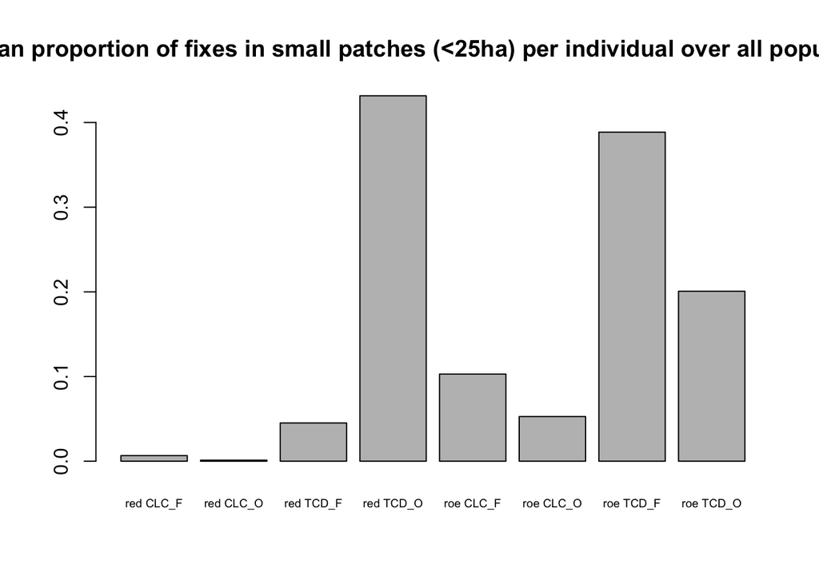

```r
barplot(r$mean,
        cex.names=0.6,
        names.arg=c(paste0(r$species, ' ', r$variable)),
        main='mean proportion of fixes in small patches (<25ha) per individual over all populations')
```

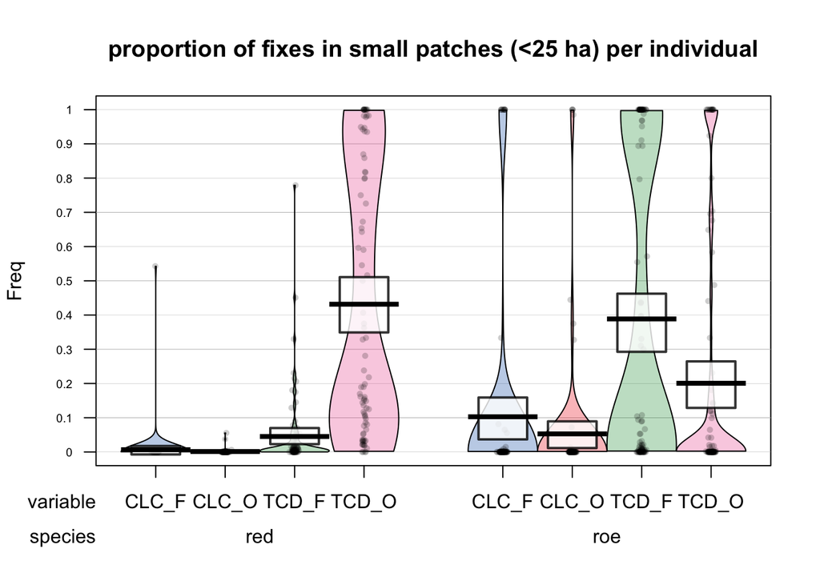

```r
#boxplot(Freq ~ species + variable, data=patch_fx, cex.axis=0.6, main='proportion of fixes in small patches (<25 ha) per individual')
pirateplot(Freq ~ variable  + species, data=patch_fx, cex.axis=0.6, main='proportion of fixes in small patches (<25 ha) per individual')
```